# Packages import

```r
library(dplyr)
library(caret)
#library(verification)
#library(nnet)
library(janitor)
library(nortest)
library(caTools)
library(glmnet)
```

# Data import

```r
getwd()
```

```
## [1] "/home/Python/Tir_shipping_prices"
```

```r
df = read.csv(file = "train_set_filtered.csv", sep = ",", header = TRUE)
testdf = read.csv(file = "test_set_filtered.csv", sep = ",", header = TRUE)
```

# Zmienne

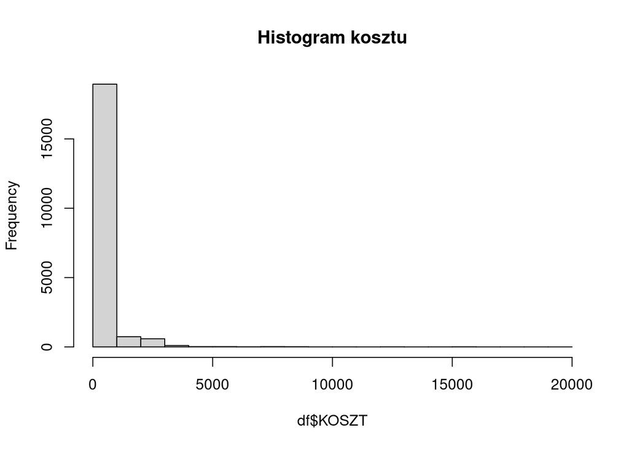

```r
hist(df$KOSZT, main="Histogram kosztu")
```

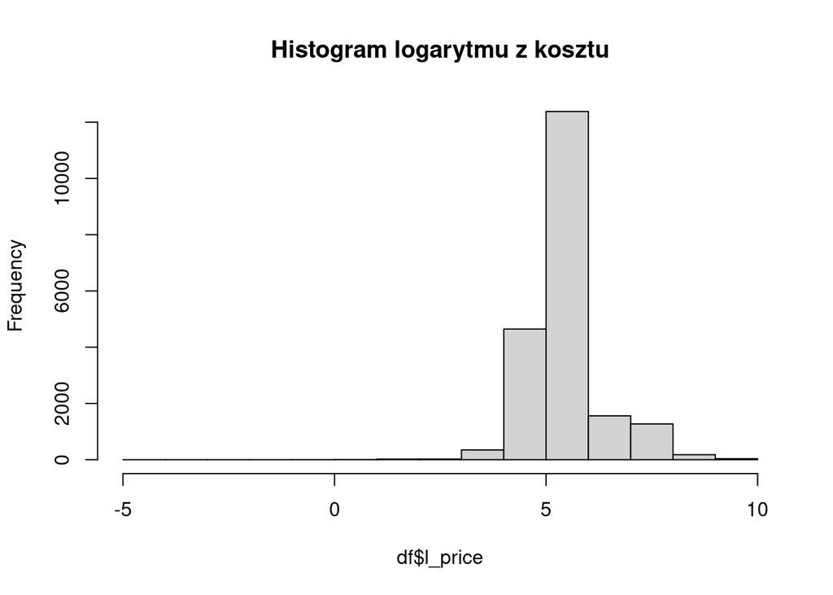

```r
df <- df %>% mutate(l_price = log(df$KOSZT))
hist(df$l_price, main="Histogram logarytmu z kosztu")
```

```r
#logarytmizujemy żeby model się lepiej zachowywał
```

The QQ chart shows that the top quartile is not exactly what should be in the normal distribution.

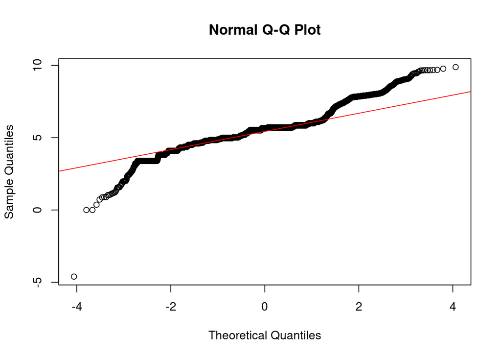

```r
qqnorm(df$l_price)
qqline(df$l_price, col = "red")
```

Nonparametric Kolmogorov-Smirnov test gives grounds to reject the hypothesis of a normal distribution. On the other hand, this test is quite sensitive to outliers and probably their presence causes the test to give grounds for rejecting the null hypothesis that the distribution of the variable is normal.

```r
nortest::lillie.test(df$l_price)
```

```
##
##  Lilliefors (Kolmogorov-Smirnov) normality test
##
## data:  df$l_price
## D = 0.1744, p-value < 2.2e-16
```

### Calkowita odleglosc

```r
summary(df$CALKOWITA_ODLEGLOSC)
```

```
##    Min. 1st Qu.  Median    Mean 3rd Qu.    Max.
##    0.00   16.70   19.36   68.21   34.04 3806.31
```

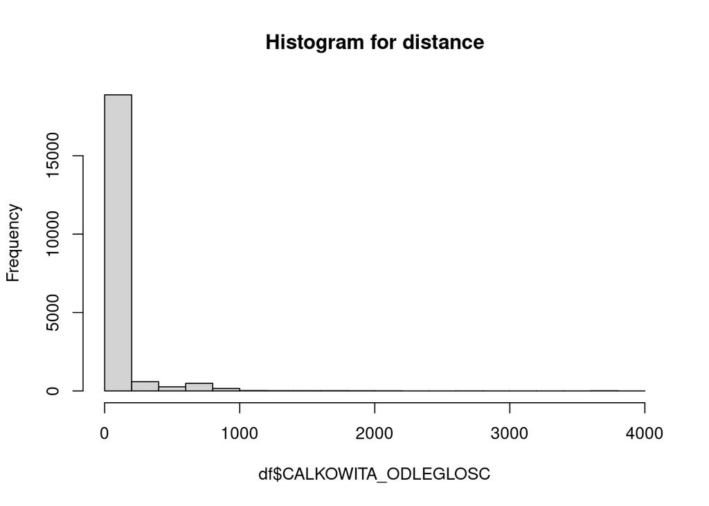

```r
hist(df$CALKOWITA_ODLEGLOSC, main="Histogram for distance")
```

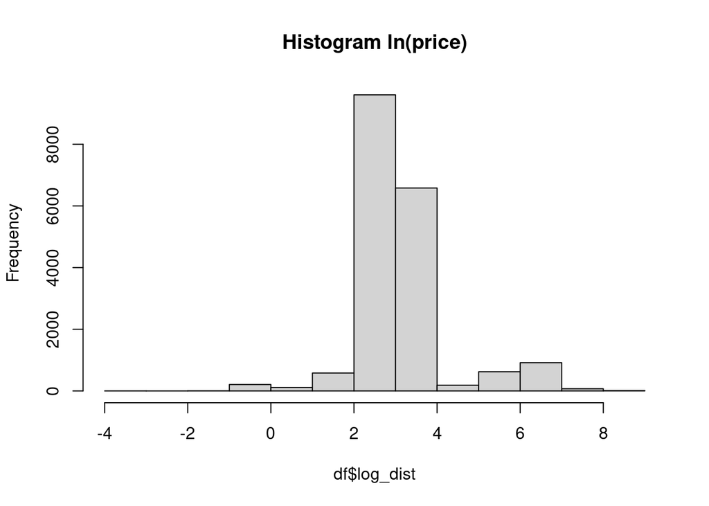

```r
df <- df %>% mutate(log_dist = log(df$CALKOWITA_ODLEGLOSC))
hist(df$log_dist, main="Histogram ln(price)")
```

```r
#log też wygląda lepiej niż bez log
```

### Liczba zaladunkow i rozladunkow

Przerobiona na poziomy 1 i >1, ponieważ za mało jest próbek >1

```r
#zmienna dyskretna, 1 vs > 1

df$LICZBA_ZALADUNKOW <- factor(df$LICZBA_ZALADUNKOW,
                      levels = c(1, 2, 3),
                      ordered = TRUE)

df$LICZBA_ZALADUNKOW[df$LICZBA_ZALADUNKOW == 1] <- 1
df$LICZBA_ZALADUNKOW[df$LICZBA_ZALADUNKOW != 1] <- 2
df$LICZBA_ZALADUNKOW[is.na(df$LICZBA_ZALADUNKOW)] <- 2

df$LICZBA_ZALADUNKOW <- droplevels(df$LICZBA_ZALADUNKOW)


testdf$LICZBA_ZALADUNKOW <- factor(testdf$LICZBA_ZALADUNKOW,
                      levels = c(1, 2, 3),
                      ordered = TRUE)

testdf$LICZBA_ZALADUNKOW[testdf$LICZBA_ZALADUNKOW == 1] <- 1
testdf$LICZBA_ZALADUNKOW[testdf$LICZBA_ZALADUNKOW != 1] <- 2
testdf$LICZBA_ZALADUNKOW[is.na(testdf$LICZBA_ZALADUNKOW)] <- 2

testdf$LICZBA_ZALADUNKOW <- droplevels(testdf$LICZBA_ZALADUNKOW)

summary(df$LICZBA_ZALADUNKOW)
```

```
##     1     2
## 18792  1678
```

```r
#zmienna dyskretna, 1 vs > 1

df$LICZBA_ROZLADUNKOW <- factor(df$LICZBA_ROZLADUNKOW,
                      levels = c(1, 2, 3, 4, 5, 6, 8),
                      ordered = TRUE)

df$LICZBA_ROZLADUNKOW[df$LICZBA_ROZLADUNKOW == 1] <- 1
df$LICZBA_ROZLADUNKOW[df$LICZBA_ROZLADUNKOW != 1] <- 2
df$LICZBA_ROZLADUNKOW[is.na(df$LICZBA_ROZLADUNKOW)] <- 2

df$LICZBA_ROZLADUNKOW <- droplevels(df$LICZBA_ROZLADUNKOW)



testdf$LICZBA_ROZLADUNKOW <- factor(testdf$LICZBA_ROZLADUNKOW,
                      levels = c(1, 2, 3, 4, 5, 6, 8),
                      ordered = TRUE)

testdf$LICZBA_ROZLADUNKOW[testdf$LICZBA_ROZLADUNKOW == 1] <- 1
testdf$LICZBA_ROZLADUNKOW[testdf$LICZBA_ROZLADUNKOW != 1] <- 2
testdf$LICZBA_ROZLADUNKOW[is.na(testdf$LICZBA_ROZLADUNKOW)] <- 2

testdf$LICZBA_ROZLADUNKOW <- droplevels(testdf$LICZBA_ROZLADUNKOW)

summary(df$LICZBA_ROZLADUNKOW)
```

```
##     1     2
## 17929  2541
```

### Czas transportu

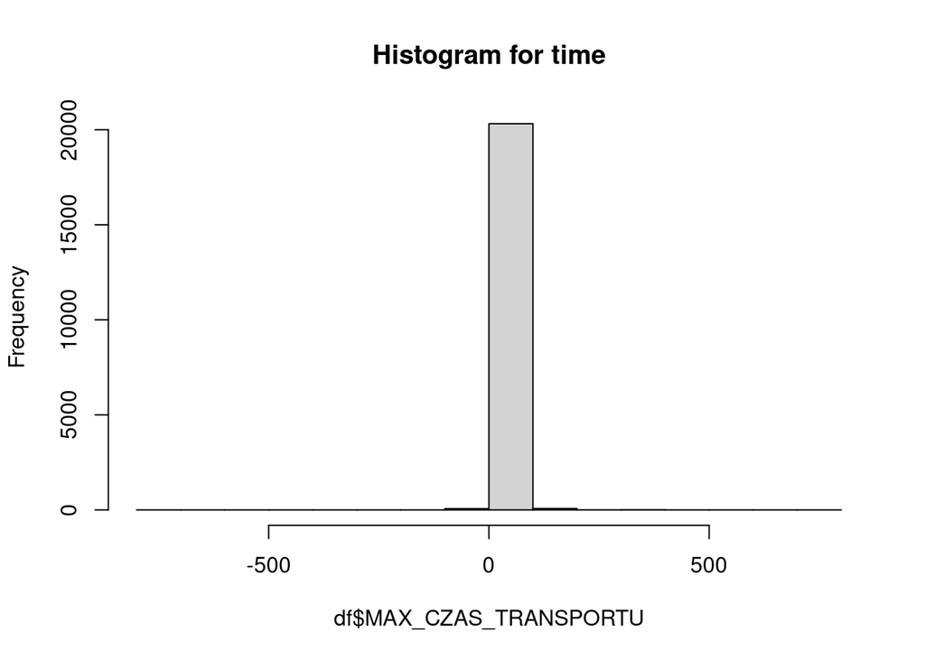

```r
hist(df$MAX_CZAS_TRANSPORTU, main="Histogram for time")
```

```r
df <- df %>% mutate(l_czas = log(df$MAX_CZAS_TRANSPORTU))
```

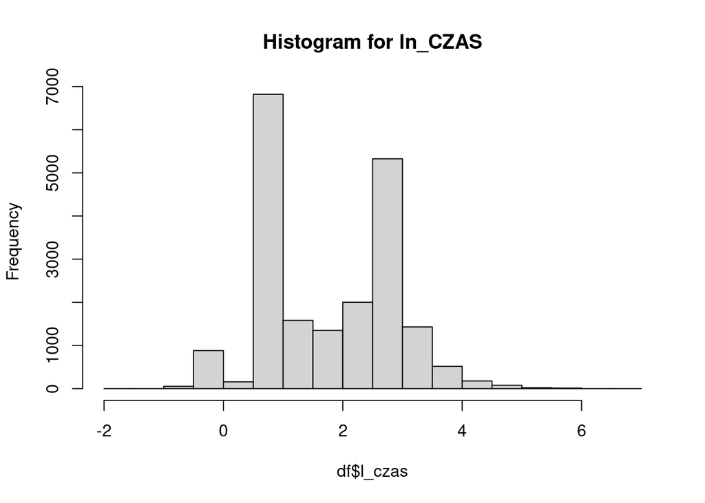

```r
hist(df$l_czas, main="Histogram for ln_CZAS")
```

```r
tabyl(df, MAX_CZAS_TRANSPORTU)
```

[output not shown]

[output cut: 682 more lines]

```
##          192.0000000    1 4.885198e-05
##          194.0000000    1 4.885198e-05
##          242.0000000    1 4.885198e-05
##          249.0000000    1 4.885198e-05
##          264.0000000    1 4.885198e-05
##          294.0000000    1 4.885198e-05
##          303.9997222    1 4.885198e-05
##          312.0000000    1 4.885198e-05
##          321.0000000    2 9.770396e-05
##          336.0000000    2 9.770396e-05
##          340.0000000    1 4.885198e-05
##          344.0000000    1 4.885198e-05
##          369.0000000    1 4.885198e-05
##          408.0000000    1 4.885198e-05
##          726.0000000    1 4.885198e-05
```

```r
#zlogarytmizowanie usuwa nam outliery ktore są <=0
```

Yet Kolmogorov-Smirnov test gives grounds for rejecting the null hypothesis.

```r
nortest::lillie.test(df$CALKOWITA_ODLEGLOSC)
```

```
##
##  Lilliefors (Kolmogorov-Smirnov) normality test
##
## data:  df$CALKOWITA_ODLEGLOSC
## D = 0.44548, p-value < 2.2e-16
```

Variables identified as discrete have been decoded into binary variables. Since some groups of observations were small in the sample, I combined them with other groups to avoid the problem of irrelevance.

```r
options(contrasts = c("contr.treatment", "contr.treatment"))
```

# Model estimation

```r
train_set = df # subset(df, data1 == TRUE)
test_set = testdf # subset(df,data1==FALSE)
```

Cross validation

```r
train.control <- trainControl(method = "cv", number = 10)
```

### Linear regression

```r
# linear model estimation

model2 <- train(KOSZT ~ TERMIN_PLATNOSCI + CZY_CHLODNIA + MIN_CZAS_TRANSPORTU + MAX_CZAS_TRANSPORTU + LICZBA_ZALADUNKOW + LICZBA_ROZLADUNKOW + CALKOWITA_ODLEGLOSC + MAX_WAGA + TONOKILOMETRY + ODLEGLOSC_NA_PUSTO + CENA_PALIWA + ODSTEP_CZASOWY + ILE_DNI_TEMU + CZAS_REALIZACJI + SZEROKOSC_ZALADUNKU + SZEROKOSC_ROZLADUNKU + DLUGOSC_ROZLADUNKU , data = train_set, method = "lm",
                trControl = train.control,
                na.action = na.exclude)

# estimation result
summary(model2)
```

```
##
## Call:
## lm(formula = .outcome ~ ., data = dat)
##
## Residuals:
##     Min      1Q  Median      3Q     Max
## -4869.0   -53.8   -10.6    49.8  8706.3
##
## Coefficients:
##                        Estimate Std. Error t value Pr(>|t|)
## (Intercept)           2.666e+02  7.544e+01   3.534 0.000411 ***
## TERMIN_PLATNOSCI      9.489e-01  1.684e-01   5.634 1.79e-08 ***
## CZY_CHLODNIA          5.408e+01  6.588e+00   8.210 2.35e-16 ***
## MIN_CZAS_TRANSPORTU   8.461e-01  3.209e-01   2.636 0.008385 **
## MAX_CZAS_TRANSPORTU  -7.468e-01  2.169e-01  -3.443 0.000576 ***
## LICZBA_ZALADUNKOW2    6.226e+01  1.049e+01   5.936 2.98e-09 ***
## LICZBA_ROZLADUNKOW2  -7.039e+01  1.056e+01  -6.668 2.67e-11 ***
## CALKOWITA_ODLEGLOSC   2.023e+00  9.530e-02  21.230  < 2e-16 ***
## MAX_WAGA              4.686e-03  7.726e-04   6.065 1.34e-09 ***
## TONOKILOMETRY         5.243e-02  5.122e-03  10.236  < 2e-16 ***
## ODLEGLOSC_NA_PUSTO    1.178e+00  9.295e-02  12.673  < 2e-16 ***
## CENA_PALIWA           2.380e-02  3.208e-03   7.417 1.25e-13 ***
## ODSTEP_CZASOWY        3.614e-01  3.794e-02   9.526  < 2e-16 ***
## ILE_DNI_TEMU         -1.986e-02  3.304e-03  -6.011 1.87e-09 ***
## CZAS_REALIZACJI       8.875e+00  3.120e-01  28.447  < 2e-16 ***
## SZEROKOSC_ZALADUNKU  -7.037e+01  1.263e+01  -5.570 2.58e-08 ***
## SZEROKOSC_ROZLADUNKU  8.059e+01  1.271e+01   6.341 2.34e-10 ***
## DLUGOSC_ROZLADUNKU   -4.237e+01  9.415e-01 -45.003  < 2e-16 ***
## ---
## Signif. codes:  0 '***' 0.001 '**' 0.01 '*' 0.05 '.' 0.1 ' ' 1
##
## Residual standard error: 237.9 on 20220 degrees of freedom
## Multiple R-squared:  0.9051, Adjusted R-squared:  0.9051
## F-statistic: 1.135e+04 on 17 and 20220 DF,  p-value: < 2.2e-16
```

```r
# predicted values
predicted_linear <- predict(model2)
```

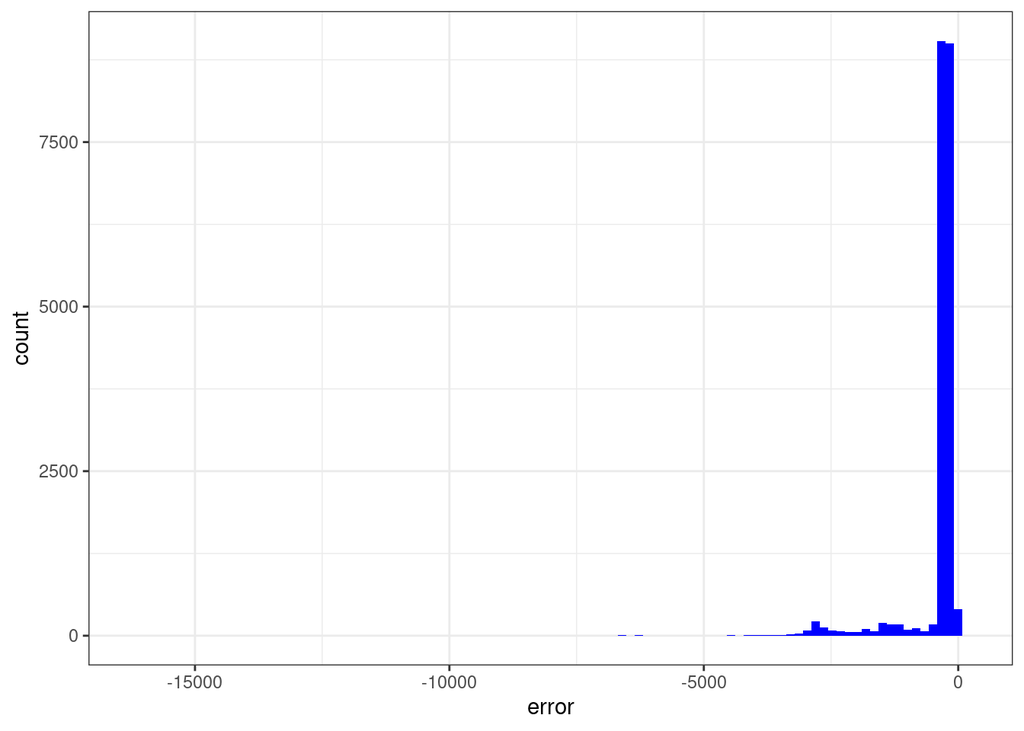

```r
# distribution of errors
ggplot(data.frame(error = train_set$l_price - predicted_linear),
       aes(x = error)) +
  geom_histogram(fill = "blue",
                 bins = 100) +
  theme_bw()
```

```r
# real values against the predicted
```

[output not shown]

Function which will help to evaluate the fit of the model to the data.

```r
regressionMetrics <- function(real, predicted) {
  # Mean Square Error
  MSE <- mean((real - predicted)^2)
  # Root Mean Square Error
  RMSE <- sqrt(MSE)
  # Mean Absolute Error
  MAE <- mean(abs(real - predicted))
  # Mean Absolute Percentage Error
  MAPE <- mean(abs(real - predicted)/real)
  # Median Absolute Error
  MedAE <- median(abs(real - predicted))
  # Mean Logarithmic Absolute Error
  MSLE <- mean((log(1 + real) - log(1 + predicted))^2)
  # Total Sum of Squares
  TSS <- sum((real - mean(real))^2)
  # Explained Sum of Squares
  RSS <- sum((predicted - real)^2)
  # R2
  R2 <- 1 - RSS/TSS

  result <- data.frame(MSE, RMSE, MAE, MAPE, MedAE, MSLE, R2)
  return(result)
}
```

Metrics for a linear model.

```r
regressionMetrics(real = test_set$KOSZT,
                  predicted = predict(model2,
                                      test_set)
)
```

```
##        MSE     RMSE      MAE      MAPE    MedAE      MSLE        R2
## 1 688633.7 829.8396 189.7549 0.5509598 106.0342 0.2727527 0.6393478
```

### Ridge model

Cross validation and lambda parameters.

```r
ctrl_cv5 <- trainControl(method = "cv", number = 5)

lambdas <- exp(log(10)*seq(-2, 9, length.out = 200))
```

Data frame preparation and model estimation.

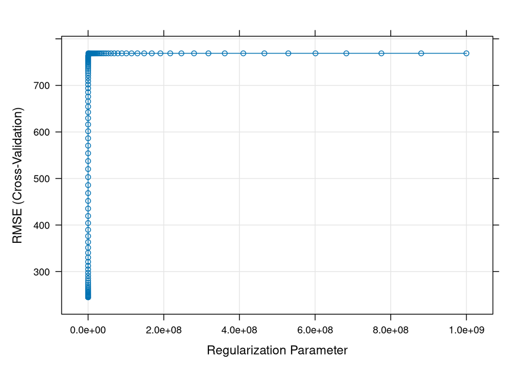

```r
parameters_ridge <- expand.grid(alpha = 0,
                                lambda = lambdas)

all_variables <- c('KOSZT', 'TERMIN_PLATNOSCI', 'CZY_CHLODNIA', 'MIN_CZAS_TRANSPORTU', 'MAX_CZAS_TRANSPORTU', 'LICZBA_ZALADUNKOW', 'LICZBA_ROZLADUNKOW',
                          'CALKOWITA_ODLEGLOSC', 'MAX_WAGA', 'TONOKILOMETRY', 'ODLEGLOSC_NA_PUSTO', 'CENA_PALIWA', 'ODSTEP_CZASOWY', 'ILE_DNI_TEMU', 'CZAS_REALIZACJI', 'SZEROKOSC_ZALADUNKU', 'DLUGOSC_ZALADUNKU', 'SZEROKOSC_ROZLADUNKU', 'SZEROKOSC_ROZLADUNKU')

ridge_model <- train(KOSZT ~ .,
                      data = train_set %>%
                        dplyr::select(all_of(all_variables)),
                      method = "glmnet",
                      tuneGrid = parameters_ridge,
                      trControl = ctrl_cv5,
                      na.action = na.exclude)

plot(ridge_model)
```

The best lambda and model prediction.

```r
ridge_model$bestTune$lambda
```

```
## [1] 65.1734
```

```r
predict(ridge_model$finalModel,
        s = ridge_model$bestTune$lambda,
        type = "coefficients")
```

```
## 18 x 1 sparse Matrix of class "dgCMatrix"
##                                s1
## (Intercept)          552.12822989
## TERMIN_PLATNOSCI       0.63270132
## CZY_CHLODNIA          63.57038291
## MIN_CZAS_TRANSPORTU    3.09602600
## MAX_CZAS_TRANSPORTU    0.03767573
## LICZBA_ZALADUNKOW2    32.42467086
## LICZBA_ROZLADUNKOW2   34.42111227
## CALKOWITA_ODLEGLOSC    1.37079055
## MAX_WAGA               0.00791976
## TONOKILOMETRY          0.06441276
## ODLEGLOSC_NA_PUSTO     1.40388530
## CENA_PALIWA            0.02447824
## ODSTEP_CZASOWY         0.31204120
## ILE_DNI_TEMU          -0.01904133
## CZAS_REALIZACJI        8.92410626
## SZEROKOSC_ZALADUNKU   -0.46116021
## DLUGOSC_ZALADUNKU    -39.84798345
## SZEROKOSC_ROZLADUNKU   4.50717868
```

Metrics for the ridge model.

```r
regressionMetrics(real = test_set$KOSZT,
                  predicted = predict(ridge_model,
                                      test_set)
)
```

```
##        MSE     RMSE      MAE      MAPE    MedAE      MSLE        R2
## 1 675587.8 821.9415 191.9485 0.5679908 110.0174 0.2816634 0.6461803
```

### LASSO model

Model estimation.

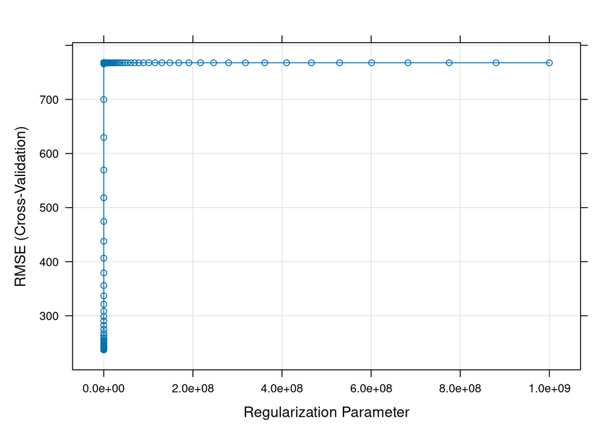

```r
parameters_lasso <- expand.grid(alpha = 1,
                                lambda = lambdas)

lasso_model <-  train(KOSZT ~ .,
                       data = train_set %>%
                       dplyr::select(all_of(all_variables)),
                       method = "glmnet",
                       tuneGrid = parameters_lasso,
                       trControl = ctrl_cv5,
                       na.action = na.exclude)

plot(lasso_model)
```

The best lambda and model prediction.

```r
lasso_model$bestTune$lambda
```

```
## [1] 0.8603464
```

```r
predict(lasso_model$finalModel,
        s = lasso_model$bestTune$lambda,
        type = "coefficients")
```

```
## 18 x 1 sparse Matrix of class "dgCMatrix"
##                                 s1
## (Intercept)          325.625447519
## TERMIN_PLATNOSCI       0.789711674
## CZY_CHLODNIA          51.028786590
## MIN_CZAS_TRANSPORTU    0.570179665
## MAX_CZAS_TRANSPORTU   -0.484416618
## LICZBA_ZALADUNKOW2    47.699131314
## LICZBA_ROZLADUNKOW2  -54.865798618
## CALKOWITA_ODLEGLOSC    2.328232857
## MAX_WAGA               0.003848444
## TONOKILOMETRY          0.036241364
## ODLEGLOSC_NA_PUSTO     0.861832881
## CENA_PALIWA            0.023316343
## ODSTEP_CZASOWY         0.314759854
## ILE_DNI_TEMU          -0.020608038
## CZAS_REALIZACJI        8.847546303
## SZEROKOSC_ZALADUNKU    .
## DLUGOSC_ZALADUNKU    -42.116929415
## SZEROKOSC_ROZLADUNKU   9.145928055
```

Metrics for the LASSO model.

```r
regressionMetrics(real = test_set$KOSZT,
                  predicted = predict(lasso_model,
                                      test_set)
)
```

```
##        MSE     RMSE      MAE     MAPE    MedAE      MSLE        R2
## 1 690808.3 831.1488 190.2036 0.552546 110.2179 0.2730503 0.6382089
```